Back to Lecture Overview

# Numerical Datatypes and Operators

- Author: Johannes Maucher
- Last Update: 27.06.2017

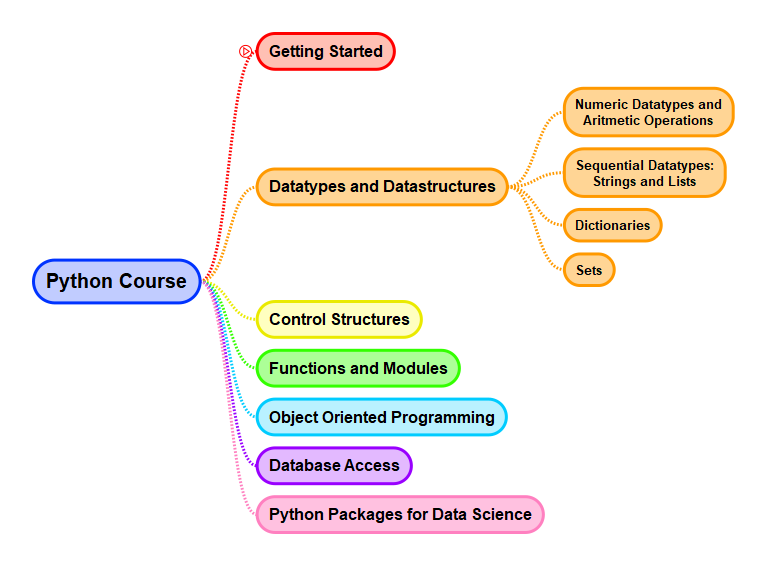

```python
from IPython.display import Image
Image(filename="../../Pics/DS_Python_Datatypes_All.png")
```

## Numerical Datatypes

In Python numerical datatypes are

- `int` and `long` for integers
- `float` for floating point numbers
- `complex` for complex numbers
- `bool` for Boolean numbers

Python is **dynamically typed**. This means, that it is not necessary to explicitly define a certain type of a variable. In Python the type of the variable is infered automatically as soon as a value is assigned to the variable. And it is possible that new types can be assigned to a variable. This is demonstrated in the following code-cell:

```python
x=5
print(type(x)) #x is of type int, because an integer has been assigned to it
x= 3.8
print(type(x)) #now x is of type float, because a floating-number has been assigned to it.
```

```
<class 'int'>
<class 'float'>
```

## Arithmetic Operations

Arithmetic operations are:

- Addition: `x+y`
- Subtraction: `x-y`
- Multiplikation: `x*y`
- Division: `x/y` (Caution! If x and y are integers, than integer division is performed)
- Remainder of integer division: `x%y`
- Integer division: `x//y`
- Power: `x**y`
- Negation: `-x`

```python
x=7
print(x)
y=3
print(y)
s=x+y
print(s)
d=x-y
print(d)
p=x*y
print(p)
```

```
7
3
10
4
21
```

Printing the value of variables can be done as in the code-cell above. However, the output of the value alone is often inappropriate, since it can be difficult to retrace the variable to which a value belongs to. It is better to print additional information in a formatted manner, as shown below:

```python
print("x =%3d"%x)
print("y =%3d"%y)
print("x+y =%3d"%(x+y))
print("x-y =%3d"%(x-y))
print("x*y =%3d"%(x*y))
print("Integer division x/y =%3d"%(x/y))
print("Float division float(x)/y =%3.4f"%(float(x)/y))
print("Remainder x%%y =%3d"%(x%y))
print("Integer division x//y =%3d"%(x//y))
print("Power x**y =%3d"%(x**y))
print("Negation -x =%3d"%(-x))
```

```
x =  7
y =  3
x+y = 10
x-y =  4
x*y = 21
Integer division x/y =  2
Float division float(x)/y =2.3333
Remainder x%y =  1
Integer division x//y =  2
Power x**y =343
Negation -x = -7
```

```python
print("Old x: %2d"%x)
print("y = %2d "%y)
x+=y
print("New x: %2d "%x)
```

```
Old x:  7
y =  3
New x: 10
```

## Comparison Operators

For the datatypes `int`, `long`, `float` and `bool` the following comparison-operators are defined: `==`, `!=`, `<`, `>`, `<=`, `=>`

```python
a=3
b=5.2
c=-4.1
d=3.0
print("a==b: %s"%(a==b))
print("a==d: %s"%(a==d))
print("a<=d: %s"%(a<=d))
print("b>c : %s"%(b>c))
print("c>d : %s"%(c>d))
```

```
a==b: False
a==d: True
a<=d: True
b>c : True
c>d : False
```

## Boolean Types

The type `bool` belongs to the numeric types, because all arithmetic operators can be applied to it. However, the value of a Boolean variable can only be `True`, which is evaluated as 1, or `False`, which is evaluated as 0. In addition to the arithmetic operations for boolean variables also the logical operators `not`, `and` and `or` are defined. Instead of `and` and `or`, also the characters `&` and `|` can be applied, respectively.

```python
ra = (a==b) and (a==d)
print(ra)
rb = (a==b) or (a==d)
print(rb)
print(not ra)
```

```
False
True
True
```

```python
ra = (a==b) & (a==d)
print(ra)
rb = (a==b) | (a==d)
print(rb)
print(ra!=rb)
```

```
False
True
True
```

## Convert Numeric Types

The type of a variable `x` can be converted (*casted*) into a new one by `typname(x)`.

```python
x=3
print("Initial type of x: %s"%type(x))
x=float(x)
print("Type after 1.st conversion: %s"%type(x))
x=3
print("Type after 2.nd conversion: %s"%type(x))
x=3.9
print("New value of x: %s"%(x))
print("Type after 3.rd conversion: %s"%type(x))
x=int(x)
print("Value after conversion from float to int: %s"%(x))
x = bool(x)
print("Type after 3.rd conversion: %s"%type(x))
print("Value after conversion from int to bool: %s"%(x))
```

```
Initial type of x: <class 'int'>
Type after 1.st conversion: <class 'float'>
Type after 2.nd conversion: <class 'int'>
New value of x: 3.9
Type after 3.rd conversion: <class 'float'>
Value after conversion from float to int: 3
Type after 3.rd conversion: <class 'bool'>
Value after conversion from int to bool: True
```

## Exercises

Exercise on numeric datatypes in Python